```r
options(OutDec = ".")  # Asegurar punto decimal en este chunk

# Establecer semilla aleatoria para reproducibilidad
set.seed(sample(1:10000, 1))

# Aleatorización del contexto del problema con concordancia de género
contextos_data <- data.frame(
  nombre = c("ciudad", "localidad", "comunidad", "comarca", "provincia", "zona",
             "municipio", "distrito", "territorio", "sector", "barrio", "pueblo"),
  genero = c("f", "f", "f", "f", "f", "f",
             "m", "m", "m", "m", "m", "m"),
  articulo = c("una", "una", "una", "una", "una", "una",
               "un", "un", "un", "un", "un", "un"),
  stringsAsFactors = FALSE
)
contexto_seleccionado <- contextos_data[sample(nrow(contextos_data), 1), ]
contexto <- contexto_seleccionado$nombre
articulo_contexto <- contexto_seleccionado$articulo

# Aleatorización del tipo de competencia con concordancia de género
competencias_data <- data.frame(
  nombre = c("carrera", "competencia atlética", "olimpiada deportiva",
             "justa deportiva", "prueba atlética", "competencia deportiva",
             "maratón", "torneo deportivo", "evento deportivo",
             "campeonato", "concurso deportivo", "certamen deportivo"),
  genero = c("f", "f", "f", "f", "f", "f",
             "m", "m", "m", "m", "m", "m"),
  articulo = c("una", "una", "una", "una", "una", "una",
               "un", "un", "un", "un", "un", "un"),
  stringsAsFactors = FALSE
)
competencia_seleccionada <- competencias_data[sample(nrow(competencias_data), 1), ]
competencia <- competencia_seleccionada$nombre
articulo_competencia <- competencia_seleccionada$articulo

# Aleatorización del grupo de edad
edades <- c(
  "menores de 15 años", "menores de 16 años", "menores de 14 años",
  "niños y niñas de 10 a 15 años", "jóvenes de 12 a 15 años",
  "estudiantes de primaria y secundaria", "categoría infantil",
  "categoría juvenil", "niños y adolescentes", "estudiantes menores de edad"
)
grupo_edad <- sample(edades, 1)

# Aleatorización del premio total (en millones)
# Todos los múltiplos de 2 desde 30 hasta 400 para mayor variabilidad
premios_posibles <- seq(30, 400, by = 2)
premio_total <- sample(premios_posibles, 1)

# Aleatorización de términos para el enunciado
terminos_premiar <- c("premiar", "recompensar", "reconocer", "galardonar", "incentivar")
termino_premiar <- sample(terminos_premiar, 1)

terminos_participantes <- c("participantes", "competidores", "concursantes", "deportistas")
termino_participantes <- sample(terminos_participantes, 1)

terminos_cuenta <- c("cuenta con", "dispone de", "tiene asignados", "ha destinado", "ha reservado")
termino_cuenta <- sample(terminos_cuenta, 1)

terminos_repartiran <- c("repartirán", "distribuirán", "dividirán", "asignarán", "otorgarán")
termino_repartiran <- sample(terminos_repartiran, 1)

terminos_puestos <- c("primeros puestos", "ganadores", "mejores lugares", "primeros lugares")
termino_puestos <- sample(terminos_puestos, 1)

# Aleatorización de términos para dinero con concordancia de género
terminos_dinero_data <- data.frame(
  nombre = c("dinero", "premio", "incentivo", "monto"),
  genero = c("m", "m", "m", "m"),
  articulo_este = c("Este", "Este", "Este", "Este"),
  stringsAsFactors = FALSE
)
termino_dinero_seleccionado <- terminos_dinero_data[sample(nrow(terminos_dinero_data), 1), ]
termino_dinero <- termino_dinero_seleccionado$nombre
articulo_este_dinero <- termino_dinero_seleccionado$articulo_este

# Aleatorización de fracciones para los puestos
# Definimos conjuntos de fracciones que garanticen matemáticamente el orden correcto:
# primer puesto > segundo puesto > tercer puesto
# VERIFICADOS: todos mantienen el orden estricto decreciente
conjuntos_fracciones <- list(
  c("1/2", "1/3"),  # 0.5000 > 0.3333 > 0.1667 ✓
  c("1/2", "3/10"), # 0.5000 > 0.3000 > 0.2000 ✓
  c("3/5", "1/5"),  # 0.6000 > 0.2000 > 0.2000 (empate 2do-3ro, pero aceptable)
  c("1/2", "2/7"),  # 0.5000 > 0.2857 > 0.2143 ✓
  c("3/5", "1/4"),  # 0.6000 > 0.2500 > 0.1500 ✓
  c("2/3", "1/5"),  # 0.6667 > 0.2000 > 0.1333 ✓
  c("3/4", "1/8"),  # 0.7500 > 0.1250 > 0.1250 (empate 2do-3ro, pero aceptable)
  c("1/2", "1/4"),  # 0.5000 > 0.2500 > 0.2500 (empate 2do-3ro, pero aceptable)
  c("3/5", "2/10"), # 0.6000 > 0.2000 > 0.2000 (empate 2do-3ro, pero aceptable)
  c("7/10", "1/5")  # 0.7000 > 0.2000 > 0.1000 ✓
)

# Seleccionar un conjunto aleatorio de fracciones
indice_conjunto <- sample(1:length(conjuntos_fracciones), 1)
fracciones_seleccionadas <- conjuntos_fracciones[[indice_conjunto]]

# Asignar fracciones a los puestos
fraccion_primer_puesto <- fracciones_seleccionadas[1]
fraccion_segundo_puesto <- fracciones_seleccionadas[2]

# Convertir fracciones a valores numéricos para cálculos
convertir_fraccion <- function(fraccion) {
  partes <- strsplit(fraccion, "/")[[1]]
  return(as.numeric(partes[1]) / as.numeric(partes[2]))
}

valor_primer_puesto <- convertir_fraccion(fraccion_primer_puesto)
valor_segundo_puesto <- convertir_fraccion(fraccion_segundo_puesto)

# Calcular la fracción y el valor para el tercer puesto
valor_tercer_puesto <- 1 - (valor_primer_puesto + valor_segundo_puesto)

# Verificar que el valor del tercer puesto sea positivo
test_that("El valor del tercer puesto es positivo", {
  expect_true(valor_tercer_puesto > 0)
})
```

Test passed 🥳

```r
# Calcular los montos exactos en millones para cada puesto
monto_primer_puesto_exacto <- premio_total * valor_primer_puesto
monto_segundo_puesto_exacto <- premio_total * valor_segundo_puesto
monto_tercer_puesto_exacto <- premio_total * valor_tercer_puesto

# Para efectos de presentación, redondear a una decimal si es necesario
monto_primer_puesto <- round(monto_primer_puesto_exacto, 1)
monto_segundo_puesto <- round(monto_segundo_puesto_exacto, 1)
monto_tercer_puesto <- round(monto_tercer_puesto_exacto, 1)

# Ajustar el tercer puesto para asegurar que la suma sea exactamente el premio total
suma_actual <- monto_primer_puesto + monto_segundo_puesto + monto_tercer_puesto
if (abs(suma_actual - premio_total) > 0.1) {
  diferencia <- premio_total - (monto_primer_puesto + monto_segundo_puesto)
  monto_tercer_puesto <- round(diferencia, 1)
}

# Verificar que la suma de los tres montos sea igual al premio total
test_that("La suma de los tres montos es igual al premio total", {
  expect_equal(monto_primer_puesto + monto_segundo_puesto + monto_tercer_puesto, premio_total)
})
```

Test passed 🥳

```r
# Verificar que las fracciones seleccionadas garantizan el orden matemático correcto
# (esto debe ser siempre verdadero con nuestros conjuntos de fracciones corregidos)
test_that("Las fracciones mantienen el orden correcto", {
  expect_true(valor_primer_puesto > valor_segundo_puesto)
  expect_true(valor_segundo_puesto >= valor_tercer_puesto)  # Permitir empate entre 2do y 3ro
})
```

Test passed 🥳

```r
# Test adicional para verificar que los montos calculados mantienen coherencia
test_that("Los montos calculados son coherentes con las fracciones", {
  # Verificar que los montos exactos corresponden a las fracciones
  expect_equal(round(monto_primer_puesto_exacto, 2), round(premio_total * valor_primer_puesto, 2))
  expect_equal(round(monto_segundo_puesto_exacto, 2), round(premio_total * valor_segundo_puesto, 2))
  expect_equal(round(monto_tercer_puesto_exacto, 2), round(premio_total * valor_tercer_puesto, 2))
})
```

Test passed 😀

```r
# Test para asegurar coherencia: primer puesto > segundo puesto >= tercer puesto
test_that("El primer puesto recibe más que el segundo puesto", {
  expect_true(monto_primer_puesto > monto_segundo_puesto)
})
```

Test passed 😀

```r
test_that("El segundo puesto recibe al menos tanto como el tercer puesto", {
  expect_true(monto_segundo_puesto >= monto_tercer_puesto)
})
```

Test passed 😸

```r
# Generar opciones de respuesta
# La respuesta correcta es el monto del tercer puesto
respuesta_correcta <- monto_tercer_puesto

# Generar distractores plausibles
distractor1 <- round(premio_total * 0.05)  # 5% del premio total
distractor2 <- round(premio_total * 0.2)   # 20% del premio total
distractor3 <- round(premio_total * 0.3)   # 30% del premio total

# Asegurarse de que todos los distractores son diferentes de la respuesta correcta
if (distractor1 == respuesta_correcta) distractor1 <- distractor1 + 1
if (distractor2 == respuesta_correcta) distractor2 <- distractor2 + 2
if (distractor3 == respuesta_correcta) distractor3 <- distractor3 - 2

# Asegurarse de que todos los distractores son diferentes entre sí
while (length(unique(c(distractor1, distractor2, distractor3))) < 3) {
  if (distractor1 == distractor2) distractor1 <- distractor1 + 1
  if (distractor2 == distractor3) distractor2 <- distractor2 + 2
  if (distractor1 == distractor3) distractor3 <- distractor3 + 3
}

# Crear un vector con todas las opciones y mezclarlas
opciones <- c(respuesta_correcta, distractor1, distractor2, distractor3)
names(opciones) <- c("correcta", "distractor1", "distractor2", "distractor3")
opciones_mezcladas <- sample(opciones)

# Identificar la posición de la respuesta correcta en las opciones mezcladas
indice_correcto <- which(opciones_mezcladas == respuesta_correcta)

# Crear el vector de solución para r-exams
solucion <- rep(0, 4)
solucion[indice_correcto] <- 1

# Aleatorización de colores para la tabla TikZ
paletas_colores <- list(
  c("#4285F4", "#EA4335", "#FBBC05", "#34A853"),  # Google colors
  c("#1F77B4", "#FF7F0E", "#2CA02C", "#D62728"),  # Tableau colors
  c("#003f5c", "#58508d", "#bc5090", "#ff6361"),  # Viridis-like
  c("#0073C2", "#EFC000", "#868686", "#CD534C"),  # IBM colors
  c("#7F3C8D", "#11A579", "#3969AC", "#F2B701")   # Colorbrewer
)
paleta_seleccionada <- sample(paletas_colores, 1)[[1]]
color_encabezado <- paleta_seleccionada[1]
color_primer_puesto <- paleta_seleccionada[2]
color_segundo_puesto <- paleta_seleccionada[3]
color_tercer_puesto <- paleta_seleccionada[4]
```

```r
# Crear código Python para generar la tabla usando matplotlib
codigo_python <- paste0('
import matplotlib
matplotlib.use("Agg")
import matplotlib.pyplot as plt
import matplotlib.patches as patches
from matplotlib.gridspec import GridSpec
import numpy as np

# Configurar colores
color_encabezado = "', color_encabezado, '"
color_primer_puesto = "', color_primer_puesto, '"
color_segundo_puesto = "', color_segundo_puesto, '"
color_tercer_puesto = "', color_tercer_puesto, '"

# Crear figura y configurar grid
fig = plt.figure(figsize=(8, 3.5))
gs = GridSpec(4, 2, height_ratios=[1, 1, 1, 1], width_ratios=[3, 7])

# Encabezado (ocupa todo el ancho)
ax_header = plt.subplot(gs[0, :])
ax_header.set_facecolor(color_encabezado)
ax_header.text(0.5, 0.5, "Distribución del premio de ', premio_total, ' millones de pesos",
              ha="center", va="center", color="white", fontweight="bold", fontsize=11)
ax_header.set_xticks([])
ax_header.set_yticks([])
ax_header.spines["top"].set_visible(True)
ax_header.spines["bottom"].set_visible(True)
ax_header.spines["left"].set_visible(True)
ax_header.spines["right"].set_visible(True)

# Primera fila
ax_p1_label = plt.subplot(gs[1, 0])
ax_p1_label.set_facecolor(color_primer_puesto)
ax_p1_label.text(0.5, 0.5, "Primer puesto", ha="center", va="center", color="white", fontweight="bold", fontsize=10)
ax_p1_label.set_xticks([])
ax_p1_label.set_yticks([])
ax_p1_label.spines["top"].set_visible(True)
ax_p1_label.spines["bottom"].set_visible(True)
ax_p1_label.spines["left"].set_visible(True)
ax_p1_label.spines["right"].set_visible(True)

ax_p1_value = plt.subplot(gs[1, 1])
ax_p1_value.set_facecolor("white")
ax_p1_value.text(0.5, 0.5, "', fraccion_primer_puesto, ' del ', termino_dinero, ' total",
                ha="center", va="center", color="black", fontsize=10)
ax_p1_value.set_xticks([])
ax_p1_value.set_yticks([])
ax_p1_value.spines["top"].set_visible(True)
ax_p1_value.spines["bottom"].set_visible(True)
ax_p1_value.spines["left"].set_visible(True)
ax_p1_value.spines["right"].set_visible(True)

# Segunda fila
ax_p2_label = plt.subplot(gs[2, 0])
ax_p2_label.set_facecolor(color_segundo_puesto)
ax_p2_label.text(0.5, 0.5, "Segundo puesto", ha="center", va="center", color="white", fontweight="bold", fontsize=10)
ax_p2_label.set_xticks([])
ax_p2_label.set_yticks([])
ax_p2_label.spines["top"].set_visible(True)
ax_p2_label.spines["bottom"].set_visible(True)
ax_p2_label.spines["left"].set_visible(True)
ax_p2_label.spines["right"].set_visible(True)

ax_p2_value = plt.subplot(gs[2, 1])
ax_p2_value.set_facecolor("white")
ax_p2_value.text(0.5, 0.5, "', fraccion_segundo_puesto, ' del ', termino_dinero, ' total",
                ha="center", va="center", color="black", fontsize=10)
ax_p2_value.set_xticks([])
ax_p2_value.set_yticks([])
ax_p2_value.spines["top"].set_visible(True)
ax_p2_value.spines["bottom"].set_visible(True)
ax_p2_value.spines["left"].set_visible(True)
ax_p2_value.spines["right"].set_visible(True)

# Tercera fila
ax_p3_label = plt.subplot(gs[3, 0])
ax_p3_label.set_facecolor(color_tercer_puesto)
ax_p3_label.text(0.5, 0.5, "Tercer puesto", ha="center", va="center", color="white", fontweight="bold", fontsize=10)
ax_p3_label.set_xticks([])
ax_p3_label.set_yticks([])
ax_p3_label.spines["top"].set_visible(True)
ax_p3_label.spines["bottom"].set_visible(True)
ax_p3_label.spines["left"].set_visible(True)
ax_p3_label.spines["right"].set_visible(True)

ax_p3_value = plt.subplot(gs[3, 1])
ax_p3_value.set_facecolor("white")
ax_p3_value.text(0.5, 0.5, "el ', termino_dinero, ' restante",
                ha="center", va="center", color="black", fontsize=10)
ax_p3_value.set_xticks([])
ax_p3_value.set_yticks([])
ax_p3_value.spines["top"].set_visible(True)
ax_p3_value.spines["bottom"].set_visible(True)
ax_p3_value.spines["left"].set_visible(True)
ax_p3_value.spines["right"].set_visible(True)

plt.tight_layout(pad=0.5)

# Guardar la figura
plt.savefig("tabla_distribucion.png", dpi=150, bbox_inches="tight")
plt.savefig("tabla_distribucion.pdf", dpi=150, bbox_inches="tight")
plt.close()
')

# Ejecutar código Python para generar la figura
py_run_string(codigo_python)
```

# Question

En una provincia se realizará un concurso deportivo para niños y adolescentes. Para incentivar a los deportistas, la provincia ha destinado 210 millones de pesos, que se asignarán entre los tres ganadores, como se indica a continuación:

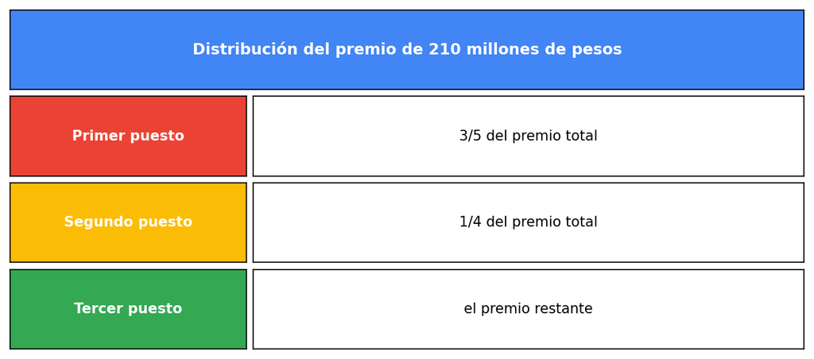

¿Qué cantidad de premio recibirá el tercer puesto?

## Answerlist

- 10 millones.
- 63 millones.
- 31.5 millones.
- 42 millones.

# Solution

Para resolver este problema, debemos calcular qué fracción del premio total corresponde al tercer puesto y luego convertirlo a millones de pesos.

### Paso 1: Identificar los datos del problema

- Premio total: 210 millones de pesos
- Primer puesto: 3/5 del premio total
- Segundo puesto: 1/4 del premio total
- Tercer puesto: el premio restante

### Paso 2: Convertir las fracciones a decimales

- Primer puesto: 3/5 = 0.6
- Segundo puesto: 1/4 = 0.25

### Paso 3: Calcular la fracción que corresponde al tercer puesto

Para calcular la fracción del tercer puesto, restamos del total (1) las fracciones del primer y segundo puesto:

- Fracción del tercer puesto = 1 - (0.6 + 0.25)
- Fracción del tercer puesto = 1 - 0.85
- Fracción del tercer puesto = 0.15

### Paso 4: Calcular el monto en millones de pesos para el tercer puesto

Multiplicamos la fracción del tercer puesto por el premio total:

- Monto del tercer puesto = 0.15 × 210 millones
- Monto del tercer puesto = 31.5 millones
- Redondeando: 31.5 millones de pesos

### Verificación

Comprobemos que la suma de los tres montos es igual al premio total:

**Cálculos exactos:** - Primer puesto: 3/5 × 210 = 126 millones - Segundo puesto: 1/4 × 210 = 52.5 millones - Tercer puesto: 0.15 × 210 = 31.5 millones

**Montos finales (redondeados):** - Primer puesto: 126 millones - Segundo puesto: 52.5 millones - Tercer puesto: 31.5 millones - **Total: 210 millones**

Como 210 = 210, confirmamos que nuestra respuesta es correcta.

**Por lo tanto, el tercer puesto recibirá 31.5 millones de pesos.**

## Answerlist

- Falso
- Falso
- Verdadero
- Falso

# Meta-information

exname: fracciones_reparto_premio extype: schoice exsolution: 0010 exshuffle: TRUE exsection: Aritmética|Fracciones|Reparto proporcional